# Pittsburgh 311 call analysis

Brian Bowling

August 23, 2018

# Introduction

This project analyzes data from the Western Pennsylvania Regional Data Center on 311 service requests in Pittsburgh. https://data.wprdc.org/dataset/311-data

This is a basic analysis of the Pittsburgh 311 service call data. It will create several charts as well as a few static and one interactive map. In the works is a per capita analysis that will use neighborhood resident and daytime populations to normalize the call data.

If you want to skip the data preparation and cleanign stuff, click on Data Analysis in the Table of Contents.

# Preparation

## Loading the packages and data

## Data prep and cleaning

There are several chores that need to be done with the analysis including: * The first datasets I analyzed had duplicate records. Since then I haven’t seen that problem but still check for it. * Fix the column names * Remove months with partial data * The 311 center receives calls about problems outside the city limits. These are relevant to an analysis of the center’s performance but not to this neighborhood analysis, so I’m going to eliminate them. * Clean up the request_type field

### column names

```r
# Preliminary cleanup
# fix column names
colnames(data_311) = tolower(make.names(colnames(data_311)))

data_311 <- rename(data_311,'id'='x_id')
```

### Duplicate records?

Are the values in the id and request_id fields unique?

```
## [1] "Number of records: 269873"
```

```
## [1] "Number of IDs: 269873"
```

```
## [1] "Number of REQUEST_IDs: 269873"
```

In previous versions, there were duplicate records. No problem this time. If there is the next time, use remove the comment marker and run the following.

```r
# data_311 <- data_311[!duplicated(data_311),]
```

### partial months

To simplify things, add a new field for creation date sans time

```r
data_311['created_date'] <- as.Date(data_311$created_on)
```

Take a look at the data to see if there are partial months at the start or end of the data period.

```r
data_311 %>%
  group_by(yr_month=paste0(year(created_date),'-', month(created_date))) %>%
  summarize(days_with_data = n_distinct(day(created_date))) %>%
  filter(days_with_data < 28)
```

```
## # A tibble: 6 x 2
##   yr_month days_with_data
##   <chr>             <int>
## 1 2015-2                1
## 2 2015-4               10
## 3 2015-5               21
## 4 2015-6               22
## 5 2015-7               25
## 6 2018-8               23
```

Have partial data in February and April of 2015 and, of course, August 2018. So remove records with created_date before May 1, 2015 and after July 31, 2018

```r
culls <- data_311$id[data_311$created_date < as.Date('2015-05-01')]
data_311 <- data_311[!data_311$id %in% culls,]
```

Have another data issue since August 2018 is obviously only a partial month. I’ll remove it from the analysis.

```r
culls <- data_311$id[data_311$created_date >= as.Date('2018-08-01')]
data_311 <- data_311[!data_311$id %in% culls,]
```

### calls from outside the city

There are two other issues. Some rows have a lot of NAs and some are classified as “OUT_OF_BOUNDS”, which means they deal with issues that are in the suburbs rather than in the city. I’m going to get rid of the latter and then take a look at what’s left of the NA rows.

```r
data_311 <- data_311[!data_311$geo_accuracy == 'OUT_OF_BOUNDS',]
```

### request_type field

Several of the problems are simply capitalization differences, so set evertying in the field to lowercase.

```r
data_311$request_type = tolower(data_311$request_type)
```

How clean is the request_type field?

```r
data_311 %>%
  group_by(request_type) %>%
  summarise(count=n()) %>%
  nrow()
```

```
## [1] 284
```

So there are 284 different request types. Eyeballing them, several of seem nearly identical. It looks like they could be grouped into general categories such as street complaints, lot complaints, etc.

The WPRDC provides a spreadsheet that categorizes requests, I’m going to import it, join it to the 311 data and see whether that cleans things up.

In my first attempts to join these two, I ended up with a lot of NAs because of inconsistencies in the request_type field. In a separate script I created a table from data_311 that included a list of request types and departments. I joined that with the categories table and exported the result to a csv that I manually edited in Excel since the R editor is too painful to use.

I’ll admit that some of the listings in the categories table don’t make much sense. Calls dealing with handicapped ramps and parking, for example, are in three different categories – Road/Street Issues, Parking and, the one that makes sense to me, Accessibility. Where the WPRDC file had a category assigned, I left it alone and generally tried to put the ones with missing categories in the same category as the ones they resembled regardless of whether the classification seemed right. I may revisit that.

The resulting file, 311-codebook-request-types-revised.csv, includes fields for the original data from both sources so you can see what I did. In cases where it wasn’t clear where a request type belonged, or where there was no department given for the referral, I coded it as “Unknown”

Join the categories to 311 data

```r
data_311 <- left_join(data_311,categories, by='request_type')
```

### Prepare for mapping

Change x and y to lat and lon

```r
data_311 <- data_311 %>%
  rename(lon = x, lat = y)
```

# Data analysis

## Take a look at the data.

```r
summary(data_311)
```

```
##        id           request_id       created_on
##  Min.   :     1   Min.   :  2932   Min.   :2015-05-01 07:13:00
##  1st Qu.: 68147   1st Qu.: 68815   1st Qu.:2016-05-12 16:45:00
##  Median :135478   Median :142471   Median :2017-03-31 13:38:00
##  Mean   :132660   Mean   :139639   Mean   :2017-02-21 18:22:16
##  3rd Qu.:197476   3rd Qu.:209247   3rd Qu.:2018-01-16 10:50:00
##  Max.   :269543   Max.   :275931   Max.   :2018-07-31 23:13:00
##
##  request_type       request_origin         status       department
##  Length:344400      Length:344400      Min.   :0.000   Length:344400
##  Class :character   Class :character   1st Qu.:1.000   Class :character
##  Mode  :character   Mode  :character   Median :1.000   Mode  :character
##                                        Mean   :1.164
##                                        3rd Qu.:1.000
##                                        Max.   :3.000
##
##  neighborhood       council_district      ward           tract
##  Length:344400      Min.   :1.000    Min.   : 0.00   Min.   :4.2e+10
##  Class :character   1st Qu.:3.000    1st Qu.:10.00   1st Qu.:4.2e+10
##  Mode  :character   Median :5.000    Median :16.00   Median :4.2e+10
##                     Mean   :4.892    Mean   :16.26   Mean   :4.2e+10
##                     3rd Qu.:7.000    3rd Qu.:21.00   3rd Qu.:4.2e+10
##                     Max.   :9.000    Max.   :32.00   Max.   :4.2e+10
##                     NA's   :4791     NA's   :5317    NA's   :3398
##  public_works_division  pli_division    police_zone     fire_zone
##  Min.   :0.000         Min.   : 0.00   Min.   :1.000   Length:344400
##  1st Qu.:2.000         1st Qu.:10.00   1st Qu.:2.000   Class :character
##  Median :3.000         Median :16.00   Median :4.000   Mode  :character
##  Mean   :3.089         Mean   :16.26   Mean   :3.603
##  3rd Qu.:5.000         3rd Qu.:21.00   3rd Qu.:5.000
##  Max.   :6.000         Max.   :32.00   Max.   :6.000
##  NA's   :5319          NA's   :5317    NA's   :5619
##       lon              lat        geo_accuracy        created_date
##  Min.   :-87.62   Min.   : 0.00   Length:344400      Min.   :2015-05-01
##  1st Qu.:-80.01   1st Qu.:40.42   Class :character   1st Qu.:2016-05-12
##  Median :-79.98   Median :40.44   Mode  :character   Median :2017-03-31
##  Mean   :-79.20   Mean   :40.05                      Mean   :2017-02-21
##  3rd Qu.:-79.93   3rd Qu.:40.46                      3rd Qu.:2018-01-16
##  Max.   :  0.00   Max.   :41.89                      Max.   :2018-07-31
##
##    category
##  Length:344400
##  Class :character
##  Mode  :character
##
##
##
##
```

Observations: Except for created_on, there is no continuous data. Everything else is categorical. Consequently, the analysis will consist mainly of counts.

Let’s start by getting a big-picture look at the request categories and origin.

```r
data_311 %>%
  group_by(category) %>%
  summarise(requests=n()) %>%
  arrange(desc(requests)) %>%
  mutate(pct_total = round(requests/sum(requests),digits=3)) %>%
  slice(1:10)
```

```
## # A tibble: 10 x 3
##    category                  requests pct_total
##    <chr>                        <int>     <dbl>
##  1 Road/Street Issues          145445     0.422
##  2 Neighborhood Issues          34140     0.099
##  3 Garbage and Litter Issues    30874     0.09
##  4 Building Maintenance         20583     0.06
##  5 Parks Issues                 18703     0.054
##  6 Utility Issues               14151     0.041
##  7 Parking                      12584     0.037
##  8 Public Safety                12330     0.036
##  9 Tree Issues                  10080     0.029
## 10 Construction Issues           7325     0.021
```

The Road/Street Issues category makes up about 42 percent of the calls.The next two are Neighborhood issues, which make up about 10 percent and Garbage and Litter Issues which make up 9 percent.

What’s the most frequent request_type, keeping in mind that there are some inconsistencies in the request_type coding.

```r
data_311 %>%
  group_by(request_type) %>%
  summarize(requests = n()) %>%
  mutate(pct_total = round(requests/sum(requests),digits=3) * 100) %>%
  arrange(desc(requests)) %>%
  slice(1:10)
```

```
## # A tibble: 10 x 3
##    request_type          requests pct_total
##    <chr>                    <int>     <dbl>
##  1 potholes                 76018      22.1
##  2 weeds/debris             22280       6.5
##  3 litter                   21640       6.3
##  4 snow/ice removal         18752       5.4
##  5 traffic                  12774       3.7
##  6 building maintenance     11194       3.3
##  7 replace/repair a sign    10500       3
##  8 leak                      9280       2.7
##  9 overgrowth                8554       2.5
## 10 refuse violations         6789       2
```

Potholes make up 22 percent while weeds/debri and litter, combined, would make up about 13 percent. Snow/ice removal makes up about 5 percent.

How doe the 311 requests come in?

```r
data_311 %>%
  group_by(request_origin) %>%
  summarize(requests = n()) %>%
  mutate(pct_total = round(requests/sum(requests),digits=3) * 100) %>%
  arrange(desc(requests)) %>%
  slice(1:10)
```

```
## # A tibble: 10 x 3
##    request_origin     requests pct_total
##    <chr>                 <int>     <dbl>
##  1 Call Center          223165      64.8
##  2 Website               66245      19.2
##  3 Control Panel         30502       8.9
##  4 Report2Gov iOS        10356       3
##  5 Twitter                8487       2.5
##  6 Report2Gov Android     4043       1.2
##  7 Text Message           1462       0.4
##  8 Report2Gov Website       73       0
##  9 Email                    57       0
## 10 QAlert Mobile iOS        10       0
```

No real surprises there. About 65 percent are phone calls and another 19 percent come from the webiste. Looks like apps and Twitter make up the rest.

For daily calls, what are the maximum, minimum, mean and median?

```r
dailies <- data_311 %>%
  group_by('year' = year(created_on), 'month' = month(created_on), 'day'=day(created_on)) %>%
  summarize(requests=n())

max_requests=max(dailies$requests)
min_requests=min(dailies$requests)
average_requests=mean(dailies$requests)
median_requests=median(dailies$requests)

rm(dailies)
```

Largest number of requests on any day was 1415. Smallest number was 4. Average number was 295.8762887. Median number was 300.5.

Let’s look at time-based counts.

How do the number of requests vary by year? month? Day of the Week? Hour?

By year

```r
data_311 %>%
  group_by('year' = year(created_on)) %>%
  summarize(requests=n())
```

```
## # A tibble: 4 x 2
##    year requests
##   <dbl>    <int>
## 1  2015    48738
## 2  2016    98624
## 3  2017   104628
## 4  2018    92410
```

Given the limited range (two partial years, two full years), there’s not enough data to do much of an annual analsis other than to note that the volume of calls seems to be increasing and will likely exceed 105,000 this year.

## Do some graphs

For looking at requests by month, use a graph instead of a table

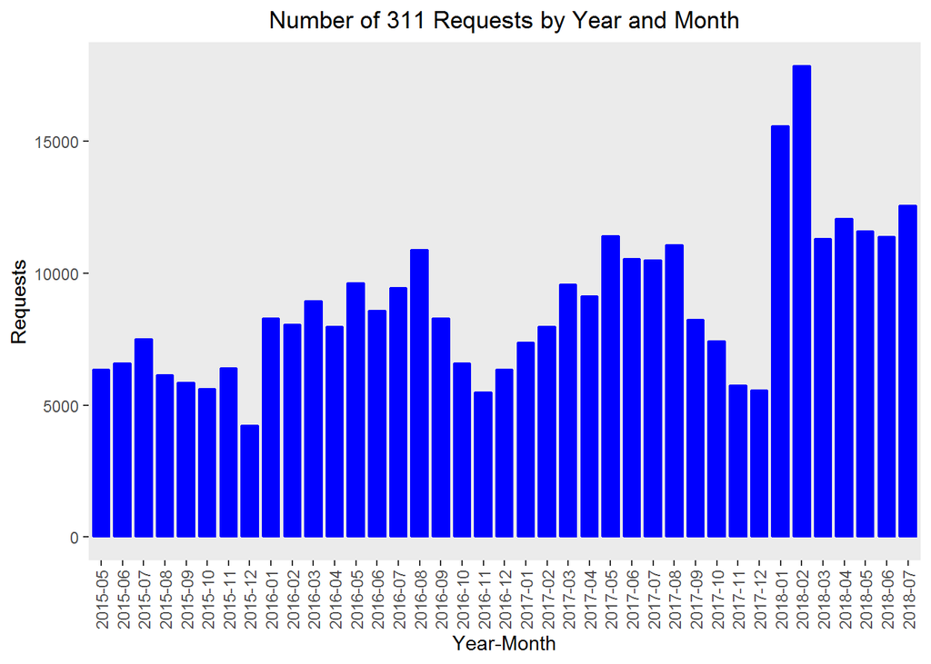

```r
data_311 %>%
  group_by('year' = year(created_on), 'month' = month(created_on)) %>%
  summarize(requests=n()) %>%
  ggplot(aes(x=paste0(year,'-',str_pad(month,2,pad='0')),y=requests)) +
  geom_col(color='blue',fill='blue',width=.8) +
  expand_limits(y=0) +
  theme(axis.text.x = element_text(angle = 90,hjust=1,vjust=0.5),
        plot.title = element_text(hjust=0.5),
        panel.grid = element_line(color='transparent')) +
  labs(title = 'Number of 311 Requests by Year and Month',
       x='Year-Month', y='Requests')
```

Save this to a separate file.

One intriguing thing is the spike in Feburary 2018. What drove that?

```r
feb_18 <- data_311 %>%
  filter(year(created_on)==2018, month(created_on)==2)

feb_18 %>%
  group_by (request_type) %>%
  summarize(counts=n()) %>%
  arrange(desc(counts)) %>%
  slice(1:10)
```

```
## # A tibble: 10 x 2
##    request_type                         counts
##    <chr>                                 <int>
##  1 potholes                               8642
##  2 snow/ice removal                       2544
##  3 litter                                  680
##  4 sign                                    347
##  5 sidewalk, lack of snow/ice removal      312
##  6 replace/repair a sign                   286
##  7 building maintenance                    270
##  8 weeds/debris                            269
##  9 abandoned vehicle (parked on street)    221
## 10 traffic                                 198
```

So Pittsburgh had a lot of 311 calls about potholes and snow/ice removal in February 2018. Let’s look at just those two request types over time.

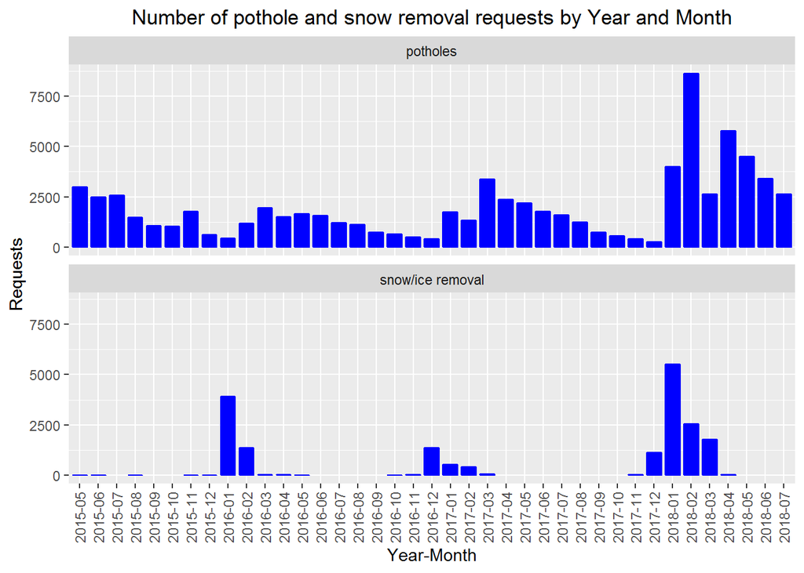

```r
data_311 %>%
  filter(request_type %in% c('potholes','snow/ice removal')) %>%
  group_by(year=year(created_on), month=month(created_on),request_type) %>%
  summarize(requests = n()) %>%
  ggplot(aes(x=paste0(year,'-',str_pad(month,2,pad='0')),y=requests)) +
  geom_col(color='blue',fill='blue',width=0.8) +
  theme(axis.text.x = element_text(angle = 90,hjust=1,vjust=0.5),
        plot.title = element_text(hjust=0.5)) +
  labs(title = 'Number of pothole and snow removal requests by Year and Month',
       x='Year-Month', y='Requests') +
  facet_wrap(~request_type,nrow=2)
```

ggsave(‘visuals/pothole_snow.png’)

Which hour sees the most requests?

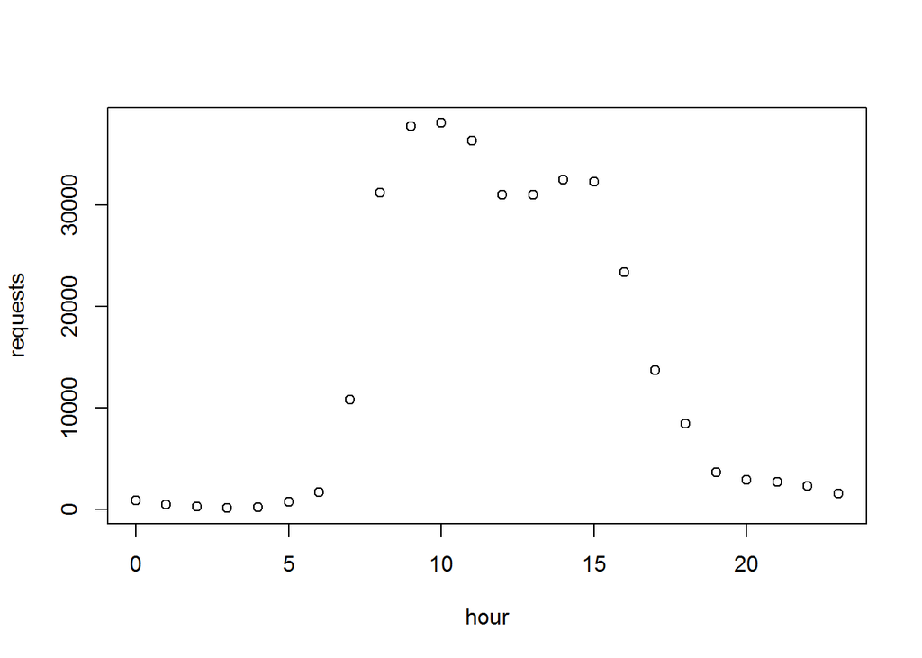

```r
requests_by_hour <- data_311 %>%
  group_by(hour=hour(created_on)) %>%
  summarize(requests = n()) %>%
  arrange(desc(requests))

plot(requests_by_hour)
```

## Make some maps

```r
# additional libraries
library(leaflet)
library(ggplot2)
library(sf)
library(leaflet.extras)
```

```r
map_file <- 'raw_data/Neighborhoods_.shp'
neighborhood_map <- st_read(map_file)
```

There are too many data points to plot data_311 directly. So aggregate some data.

```r
neighborhood_request_count <- data_311 %>%
  group_by(neighborhood) %>%
  summarize(requests = n())
```

Now put the data together with the shapefile

```r
data_311_map <- left_join(neighborhood_map,neighborhood_request_count,by=c('hood'='neighborhood'))
```

Map it.

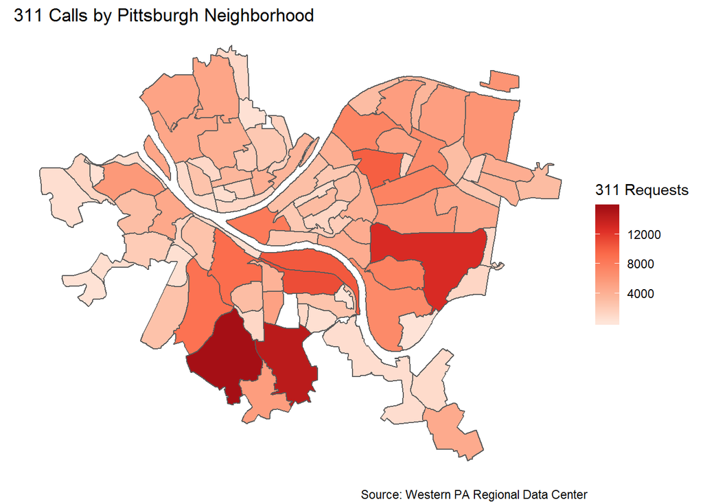

```r
ggplot(data_311_map) +
  geom_sf(aes(fill=requests)) +
  scale_fill_distiller(palette="Reds",direction=1, name="311 Requests") +
  labs(title="311 Calls by Pittsburgh Neighborhood",
       caption="Source: Western PA Regional Data Center") +
  theme_void() +
  theme(panel.grid.major = element_line(colour = 'transparent'))
```

```r
ggsave('visuals/static_map.png')
```

Kind of interesting, but would be more interesting to have it as an interactive map.

```r
popup_sb <- paste0(data_311_map$hood, " 311 calls: ", as.character(data_311_map$requests))

pal_sb <- colorNumeric("Reds", domain=data_311_map$requests)

leaflet() %>%
  addProviderTiles(providers$CartoDB.Positron) %>%
  setView(-80, 40.44, zoom=12) %>%
  addPolygons(data=data_311_map,
              fillColor= ~pal_sb(data_311_map$requests),
              fillOpacity=0.9,
              weight=0.2,
              smoothFactor = 0.2,
              highlightOptions = highlightOptions(
                weight=5,
                color= "#666",
                fillOpacity = 0.7,
                bringToFront = TRUE
              ),
              label=popup_sb,
              labelOptions = labelOptions(
                style = list("font-weight" = "normal", padding = "3px 8px"),
                textsize = "15px",
                direction = "auto")
              ) %>%
  addLegend(pal = pal_sb,
            values = data_311_map$requests,
            position = "bottomright",
            title = "311 calls by Neighborhood")
```

[interactive chart not shown]